# Markdown and Github Code

## Headers

# First level

## Second Level

### Third Level

## *Text Emphasis*

### *Italics*

You can make a *phrase* *italicized* two ways: by wrapping it in a single set of *(astericks) or _ (underscores)

### **Bold text**

Similarly there are a couple of ways to make a **phrase** **bold**: by using two sets of ** (asterics) or __ (underscores)

## Numbered lists

1. List item 1
2. List item 2
3. List item 3

## Numbered lists with subpoints

1. List item 1
   - Subpoint 1
2. List item 2
   - Subpoint 2
3. List item 3
   - Subpoint 3

## Plain list

- List item 1
  - Subpoint 1
    - Subsubpoint 1
- List item 2
  - Subpoint 2
  - Subsupoint 2
- List item 3
  - Subpoint 3
    - Subsubpoint 3

## Don’t forget your spaces

-This is what happens -If you don’t include a space after the dash

## Paragraphs

Writing a paragraph is simple, you start anywhere and you just write the text which you want to read.

Once you are ready for a new paragraph all you have to do is leave a blank line between the last sentence of the previous paragraph and the first sentence of the new paragraph. Don’t expect there to be the normal indents on each paragraph thought!

See?

## Hyperlinks and Images

- [The website for class](http://politicaldatascience.com/)

[figure not shown]

A computer with data

## Code Chunks

## How to add code

To add code ‘inline’, use three ``` (back quote keys) [Don’t confuse this with the apostrophe key]. After adding the three back quote keys, you will then include the language which you want to run in brackets {r}. There are various options you can use about whether you want the code to actually be displayed or evaluated.

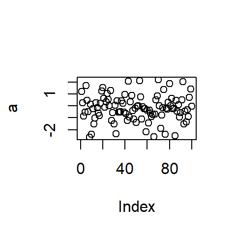

```r
# You can show the code and the output and shut off warnings
a <- rnorm(100)
plot(a)
```

```r
#library(fivethirtyeight)
fivethirtyeight::trump_twitter$text[1:5,]
# You can load in packages
# You can choose to show the code but not evaluate it
```

You can chose to evaluate a code chunk but choose not to show the code

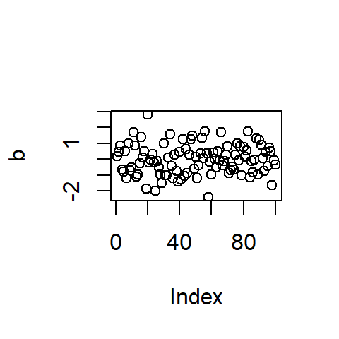

In addition to showing code and its output you can format results. If you have a set of data and you want to show summary statistics you can use the package kable to produce a nice table.

```r
knitr::kable(iris[1:5, ], caption = 'A caption')
```

A caption

| Sepal.Length | Sepal.Width | Petal.Length | Petal.Width | Species |
| --- | --- | --- | --- | --- |
| 5.1 | 3.5 | 1.4 | 0.2 | setosa |
| 4.9 | 3.0 | 1.4 | 0.2 | setosa |
| 4.7 | 3.2 | 1.3 | 0.2 | setosa |
| 4.6 | 3.1 | 1.5 | 0.2 | setosa |
| 5.0 | 3.6 | 1.4 | 0.2 | setosa |

Alternatively, if you want to show an output of a regression analysis, you can use do a summary of the model for a neat output.

```r
fit <- lm(Sepal.Length~Species, data=iris)
summary(fit)
```

```
##
## Call:
## lm(formula = Sepal.Length ~ Species, data = iris)
##
## Residuals:
##     Min      1Q  Median      3Q     Max
## -1.6880 -0.3285 -0.0060  0.3120  1.3120
##
## Coefficients:
##                   Estimate Std. Error t value Pr(>|t|)
## (Intercept)         5.0060     0.0728  68.762  < 2e-16 ***
## Speciesversicolor   0.9300     0.1030   9.033 8.77e-16 ***
## Speciesvirginica    1.5820     0.1030  15.366  < 2e-16 ***
## ---
## Signif. codes:  0 '***' 0.001 '**' 0.01 '*' 0.05 '.' 0.1 ' ' 1
##
## Residual standard error: 0.5148 on 147 degrees of freedom
## Multiple R-squared:  0.6187, Adjusted R-squared:  0.6135
## F-statistic: 119.3 on 2 and 147 DF,  p-value: < 2.2e-16
```